# Covid19 EDA

```python
import numpy as np
import pandas as pd
import seaborn as sns
import matplotlib.pyplot as plt
%matplotlib inline
from IPython.display import Image
```

## Ideas on what to do

Features to predict on: #deaths, #cases, (measurement that curve is flattening), %death/case

1.) Feature selection (choose best feature that predicts high deaths/cases)

1. Plot out variance on each feature?
2. Run logistic regression on each feature (does not account for correlations)
3. Determine best subset of features (seems difficult if not just brute-forcing)
4. Something to do with PCA (how to extract features that are within the eigenvectors?

2.) Using timeseries, determine which counties have lowered their case/death count

1. Same as #1 but determine good features for lowering case/death count (flattening the curve)

## Interesting features in datasets

### Counties:

1. Rural-UrbanContinuumCode2013 (urban/rural)
2. Demographic Info
3. Health Resource Availability (#ICU beds, etc.)
4. Health Outcomes and Risk Factors (other health factors can worsen
5. **Social Distancing and Mobility (private data)**

### States

1. Doesn't seem as useful - just number of cases in different state (including China, etc.)
2. No data on the states (so going by county seems better)

## Load Data

```python
states = pd.read_csv('covid19/4.18states.csv')
counties = pd.read_csv('covid19/abridged_couties.csv')
cases = pd.read_csv('covid19/time_series_covid19_confirmed_US.csv')
deaths = pd.read_csv('covid19/time_series_covid19_deaths_US.csv')
```

# 1) Data Cleaning and Preprocessing

### Deaths and Cases

```python
print('Num rows:', len(deaths))
print('Num cols:', len(deaths.columns))
s = deaths.isnull().sum(axis=0)
s.loc[s > 0]
```

```
Num rows: 3255
Num cols: 100
```

```
FIPS      4
Admin2    7
dtype: int64
```

```python
print('Num rows:', len(cases))
print('Num cols:', len(cases.columns))
s = cases.isnull().sum(axis=0)
s.loc[s > 0]
```

```
Num rows: 3255
Num cols: 99
```

```
FIPS      4
Admin2    7
dtype: int64
```

```python
for col in deaths.columns:
    if col not in cases.columns:
        print(col)
```

```
Population
```

```python
# Verify that the NaNs in FIPS correspond between deaths and cases
print(deaths[deaths['FIPS'].isnull()]['Admin2'])
print(cases[cases['FIPS'].isnull()]['Admin2'])
```

```
3147                          Dukes and Nantucket
3148                                  Kansas City
3253    Michigan Department of Corrections (MDOC)
3254       Federal Correctional Institution (FCI)
Name: Admin2, dtype: object
3147                          Dukes and Nantucket
3148                                  Kansas City
3253    Michigan Department of Corrections (MDOC)
3254       Federal Correctional Institution (FCI)
Name: Admin2, dtype: object
```

From the cells above, we see that the `deaths` and `cases` dataframes are very similar. They have all the same columns except that `cases` doesn't have the `Population` column, and the two dataframes share the same rows that have NaNs in the `FIPS` and `Admin2` columns.

Because there are only 4 out of 3255 rows missing value in `FIPS` we decide to drop those, and ignore `Admin2` as it is only the name of the county and we can fill them in later with their respective FIPS code if needed. We will also ignore filling in `Population` until we decide it is needed later.

```python
# Verify 4 rows were deleted
deaths = deaths[deaths['FIPS'].notnull()]
cases = cases[cases['FIPS'].notnull()]
print('Deaths new num rows:', len(deaths))
print('Cases new num rows:', len(cases))
```

```
Deaths new num rows: 3251
Cases new num rows: 3251
```

### Counties

There are a total of 87 columns in the counties dataset, but as we can see that some of the columns have a very significant amount of NaNs. Later when we try to model what are key indicators of cases and deaths of coronavirus, we will decide what cutoff to use to drop columns. An example would be if there are more than 324 NaNs (over 10% of the rows are missing data) we could drop the column.

```python
# Counties Dataset
print('Num rows:', len(counties))
print('Num cols:', len(counties.columns))
print("Number of nans in each column:")
counties.isnull().sum(axis=0).sort_values(ascending=False)[:10]
# np.array(counties.isnull().sum(axis=0).tolist())
```

```
Num rows: 3244
Num cols: 87
Number of nans in each column:
```

```
3-YrMortalityAge1-4Years2015-17      3179
mortality2015-17Estimated            3149
3-YrMortalityAge5-14Years2015-17     3149
3-YrMortalityAge<1Year2015-17        2772
3-YrMortalityAge15-24Years2015-17    2610
3-YrMortalityAge25-34Years2015-17    2270
3-YrMortalityAge35-44Years2015-17    1916
3-YrDiabetes2015-17                  1744
HPSAUnderservedPop                   1141
HPSAServedPop                        1141
dtype: int64
```

```python
MINIMUM_DATA_POINTS = 2000
number_nans_in_col = np.array(counties.isnull().sum(axis=0).tolist())
high_nan_idx= np.where(number_nans_in_col > MINIMUM_DATA_POINTS)[0]
high_nan_cols = [counties.columns[i] for i in high_nan_idx]
counties = counties.drop(high_nan_cols, axis=1)
print('Num rows:', len(counties))
print('Num cols:', len(counties.columns))
```

```
Num rows: 3244
Num cols: 81
```

Similarly, some of the rows in the dataset have very few data entries for each feature. In an extreme example, the last two rows for New York City and Kansas City have 0 features or data points. Rows that are missing values for more than 40 features are dropped from the table

```python
print("Number of nans in each county:")
counties.set_index("CountyName").isnull().sum(axis=1).sort_values(ascending=False)[:10]
```

```
Number of nans in each county:
```

```
CountyName
Kansas City                        78
Dade                               78
Yellowstone Nat Park               78
South Boston City                  78
New York City                      78
Clifton Forge City                 76
Aguijan                            75
Prince of Wales-Outer Ketchikan    75
Rota                               75
Skagway-Hoonah-Angoon              75
dtype: int64
```

```python
MINIMUM_FEATURES = 40
number_nans_in_row = np.array(counties.isnull().sum(axis=1).tolist())
high_nan_idx= np.where(number_nans_in_row > MINIMUM_FEATURES)[0]
counties = counties.drop(high_nan_idx, axis=0)
print('Num rows:', len(counties))
print('Num cols:', len(counties.columns))
```

```
Num rows: 3225
Num cols: 81
```

The data seems to be ordered relatively geographically (states are grouped together). We will make the assumption that rows consecutive rows will have similar values, so we will fill in the NaNs using `ffill` followed by `bfill` to fill in all values. This approach solves the issue with determining what a mean or median is for categorical data points.

```python
# Verify no for NaNs
counties = counties.ffill().bfill()
counties.isnull().sum(axis=0).sort_values(ascending=False)[:5]
```

```
HPSAUnderservedPop                0
PopMale10-142010                  0
#EligibleforMedicare2018          0
MedicareEnrollment,AgedTot2017    0
3-YrDiabetes2015-17               0
dtype: int64
```

### Removing features with 0 variance

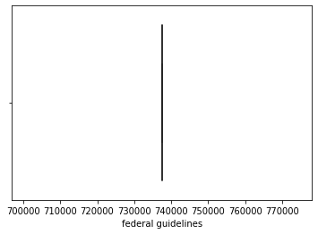

```python
sns.boxplot(counties['federal guidelines'],color='green',orient='h')
```

```python
print("Removed Features: ")
for col in counties:
    data = counties[col]
    if data.dtype == 'float64':
        if np.max(data) - np.min(data) < 1:
            print("\t" + col)
            counties = counties.drop(col, axis=1)
print('Num rows:', len(counties))
print('Num cols:', len(counties.columns))
```

```
Removed Features:
	FracMale2017
	federal guidelines
	foreign travel ban
Num rows: 3225
Num cols: 78
```

### Normalization

Some features have values that are much larger than other features. For example, values for population will be much higher than values for population density. To prevent these larger values from dominating predictions, we normalize and demean each quantitative feature, leaving categorical features the same.

```python
for col in counties:
    data = counties[col]
    if data.dtype == 'float64':
        counties[col] = (data - np.mean(data)) / np.std(data)
```

# 2) Exploratory Data Analysis (EDA)

```
Removed categorical features:
	countyFIPS
	CountyName
	StateName
	State
	CensusRegionName
	CensusDivisionName
```

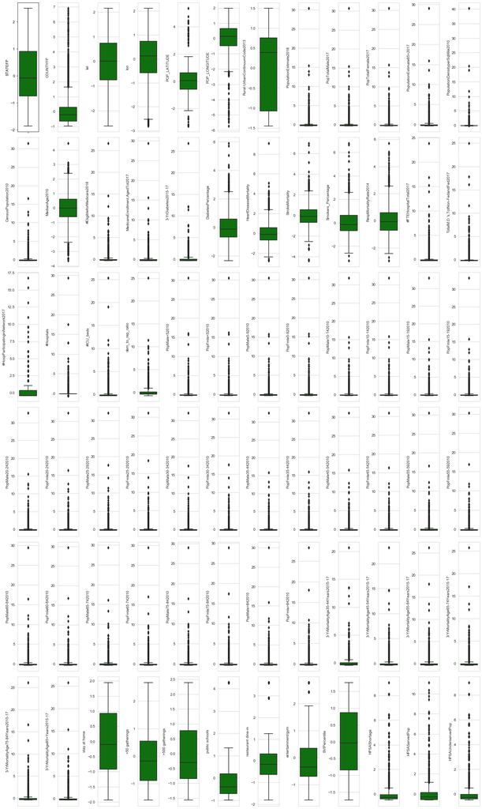

```python
plt.rcParams.update({'figure.max_open_warning': 0})

quan_counties = counties.copy()
print("Removed categorical features: ")
for col in quan_counties:
    data = quan_counties[col]
    if data.dtype != 'float64':
        print("\t" + col)
        quan_counties = quan_counties.drop(col, axis=1)

df = quan_counties
l = df.columns.values
number_of_columns=12
number_of_rows = len(l)-1/number_of_columns
plt.figure(figsize=(18,5*number_of_rows))
for i in range(0,len(l)):
    plt.subplot(number_of_rows + 1,number_of_columns,i+1)
    sns.set_style('whitegrid')
    sns.boxplot(df[l[i]],color='green',orient='v')
plt.tight_layout()
```

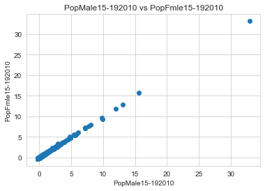

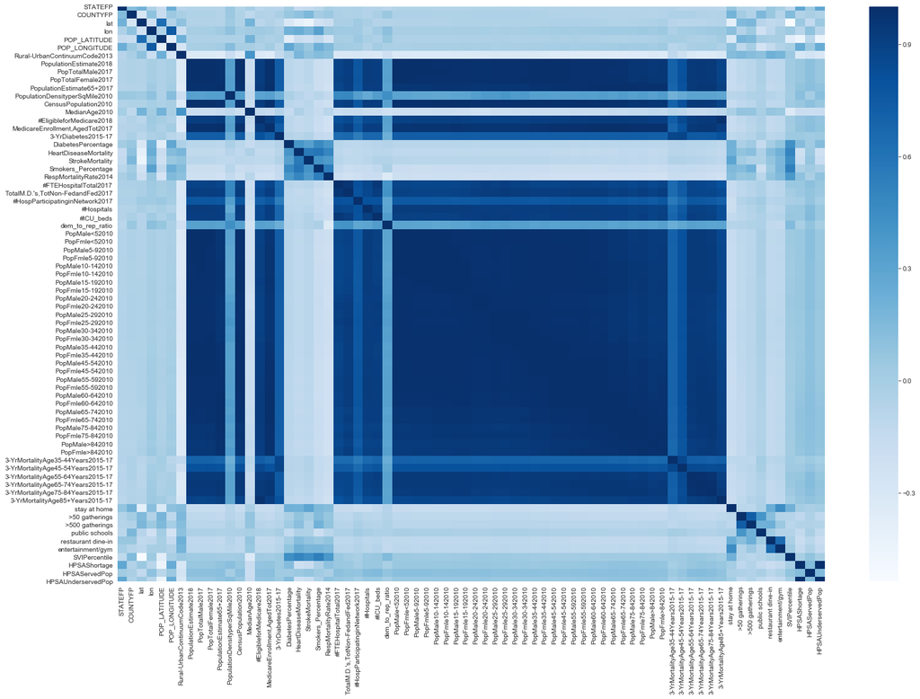

```python
plt.scatter(counties['PopMale15-192010'], counties['PopFmle15-192010'])
plt.xlabel('PopMale15-192010')
plt.ylabel('PopFmle15-192010')
plt.title("PopMale15-192010 vs PopFmle15-192010")
plt.figure(figsize=(24,16))
a = sns.heatmap(quan_counties.corr(),cmap='Blues',annot=False)
# a.set_axis_labels("Features", "Features")
# quan_counties.corr()
a
```

### Boxplots

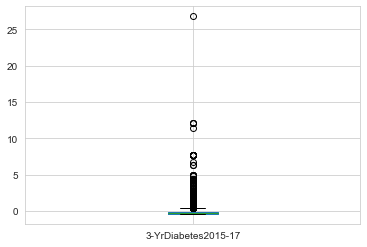

```python
df.boxplot(["3-YrDiabetes2015-17"])
```

# Distributions

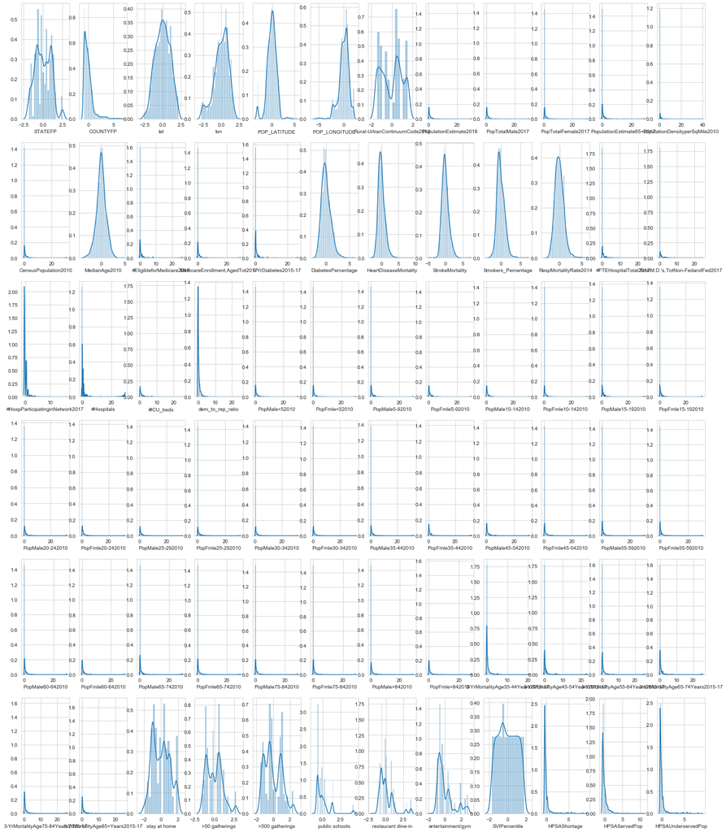

```python
l = df.columns.values
number_of_columns=12
number_of_rows = len(l)-1/number_of_columns
plt.figure(figsize=(2*number_of_columns,5*number_of_rows))
for i in range(0,len(l)):
    plt.subplot(number_of_rows + 1,number_of_columns,i+1)
    sns.distplot(df[l[i]],kde=True)
```

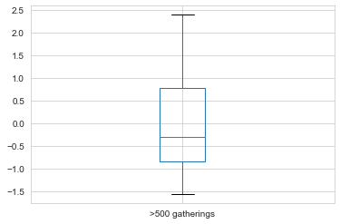

```python
counties[">50 gatherings"]
df.boxplot([">500 gatherings"])
```

# 3) Prediction Methods

```python
counties["countyFIPS"] = counties["countyFIPS"].astype(int)

deaths['FIPS'] = deaths['FIPS'].astype(int)
counties_deaths = counties.set_index(['countyFIPS']).join(deaths.set_index("FIPS"), how='inner')
```

```python
cases["totalCases"] = cases["4/9/20"] + cases["4/10/20"] + \
                     cases["4/11/20"] + cases["4/12/20"] + \
                     cases["4/13/20"] + cases["4/14/20"] + \
                     cases["4/15/20"] + cases["4/16/20"] + \
                     cases["4/17/20"] + cases["4/18/20"]
cases['FIPS'] = cases['FIPS'].astype(int)
counties_deaths = counties_deaths.join(cases[['FIPS', 'totalCases']].set_index("FIPS"), how='inner')
```

```python
cases[['FIPS', 'totalCases']]
```

|  | FIPS | totalCases |
| --- | --- | --- |
| 0 | 60 | 0 |
| 1 | 66 | 1332 |
| 2 | 69 | 119 |
| 3 | 72 | 9122 |
| 4 | 78 | 505 |
| ... | ... | ... |
| 3248 | 90053 | 5862 |
| 3249 | 90054 | 0 |
| 3250 | 90055 | 2 |
| 3251 | 90056 | 0 |
| 3252 | 99999 | 1030 |

3251 rows × 2 columns

```python
counties_deaths["totalDeaths"] = counties_deaths["4/9/20"] + counties_deaths["4/10/20"] + \
                                 counties_deaths["4/11/20"] + counties_deaths["4/12/20"] + \
                                 counties_deaths["4/13/20"] + counties_deaths["4/14/20"] + \
                                 counties_deaths["4/15/20"] + counties_deaths["4/16/20"] + \
                                 counties_deaths["4/17/20"] + counties_deaths["4/18/20"]
```

```python
counties_deaths_Y = counties_deaths
```

```python
counties_deaths
```

|  | STATEFP | COUNTYFP | CountyName | StateName | State | lat | lon | POP_LATITUDE | POP_LONGITUDE | CensusRegionName | ... | 4/11/20 | 4/12/20 | 4/13/20 | 4/14/20 | 4/15/20 | 4/16/20 | 4/17/20 | 4/18/20 | totalCases | totalDeaths |
| --- | --- | --- | --- | --- | --- | --- | --- | --- | --- | --- | --- | --- | --- | --- | --- | --- | --- | --- | --- | --- | --- |
| 1001 | -1.859112 | -0.955075 | Autauga | AL | Alabama | -1.187502 | 0.456038 | -0.890312 | 0.383511 | South | ... | 1 | 1 | 1 | 1 | 1 | 1 | 2 | 2 | 213 | 12 |
| 1003 | -1.859112 | -0.936366 | Baldwin | AL | Alabama | -1.556236 | 0.362066 | -1.209442 | 0.289002 | South | ... | 1 | 1 | 1 | 2 | 2 | 2 | 2 | 2 | 815 | 15 |
| 1005 | -1.859112 | -0.917656 | Barbour | AL | Alabama | -1.323811 | 0.564593 | -0.997648 | 0.471754 | South | ... | 0 | 0 | 0 | 0 | 0 | 0 | 0 | 0 | 112 | 0 |
| 1007 | -1.859112 | -0.898947 | Bibb | AL | Alabama | -1.093581 | 0.414331 | -0.803552 | 0.336302 | South | ... | 0 | 0 | 0 | 0 | 0 | 0 | 0 | 0 | 173 | 0 |
| 1009 | -1.859112 | -0.880238 | Blount | AL | Alabama | -0.890688 | 0.463250 | -0.652394 | 0.376258 | South | ... | 0 | 0 | 0 | 0 | 0 | 0 | 0 | 0 | 153 | 0 |
| ... | ... | ... | ... | ... | ... | ... | ... | ... | ... | ... | ... | ... | ... | ... | ... | ... | ... | ... | ... | ... | ... |
| 56037 | 1.510462 | -0.618305 | Sweetwater | WY | Wyoming | 0.678175 | -1.477386 | 0.594553 | -1.315647 | West | ... | 0 | 0 | 0 | 0 | 0 | 0 | 0 | 0 | 84 | 0 |
| 56039 | 1.510462 | -0.599596 | Teton | WY | Wyoming | 1.099150 | -1.624522 | 0.907541 | -1.426627 | West | ... | 0 | 0 | 0 | 0 | 0 | 0 | 0 | 0 | 557 | 0 |
| 56041 | 1.510462 | -0.580886 | Uinta | WY | Wyoming | 0.603030 | -1.622962 | 0.544118 | -1.425372 | West | ... | 0 | 0 | 0 | 0 | 0 | 0 | 0 | 0 | 43 | 0 |
| 56043 | 1.510462 | -0.562177 | Washakie | WY | Wyoming | 1.139160 | -1.373058 | 0.992246 | -1.212542 | West | ... | 0 | 0 | 0 | 0 | 0 | 0 | 0 | 0 | 51 | 0 |
| 56045 | 1.510462 | -0.543467 | Weston | WY | Wyoming | 1.125734 | -1.101535 | 0.975577 | -0.944329 | West | ... | 0 | 0 | 0 | 0 | 0 | 0 | 0 | 0 | 0 | 0 |

3140 rows × 178 columns